# An Ensemble Model to Predict Soybean Grain Yield

DA5030

Merlin Dassanayake

Summer 2024

### Background Data & Motivations

Soybeans are a very important legume that is grown and used all over the world for various different products. The utility of the soybean is a huge reason as to why it is “one of the main agricultural crops in the world, with a current production estimated at 399.50 million tons”. (de Oliveria et al., 2023) Crops have been selectively grown throughout history, but as we now live in an age where plant genetics give rise to genetic modification, there exist many different cultivars, or types of cultivated plants, on the market. The study by de Oliveira et al., 2023 aimed to look at 40 different cultivars and farming conditions on the overall grain yield of the crop measured in kg ha-1. Using this dataset, three different machine learning models will be used to create prediction models for the grain yield based on the various features provided. Both a homogenous and heterogenous ensemble model will also be created and each models performance and metrics will be calculated. Being able to use machine learning to help predict grain yield can provide insight into optimal growing conditions and cultivars to be used, which given the scale of soybean farming, can potentially result in a large financial and business impact for farmers.

### Data Acquisition

The dataset is first loaded into R using the URL provided by the researchers. Taking a look at the structure of the data frame, we can see that there exist 320 rows of data, with 11 columns or features, which is correct.

### Data Exploration

```r
str(soybeans)
```

```
'data.frame':   320 obs. of  11 variables:
 $ Season    : int  1 1 1 1 1 1 1 1 1 1 ...
 $ Cultivar  : Factor w/ 40 levels "74K75RSF CE",..: 32 32 32 32 29 29 29 29 2 2 ...
 $ Repetition: int  1 2 3 4 1 2 3 4 1 2 ...
 $ PH        : num  58.8 58.6 63.4 60.3 81.2 ...
 $ IFP       : num  15.2 13.4 17.2 15.3 18 ...
 $ NLP       : num  98.2 102 100.4 100.2 98.8 ...
 $ NGP       : num  178 195 203 192 173 ...
 $ NGL       : num  1.81 1.85 2.02 1.89 1.75 1.85 1.7 1.77 2.3 2.62 ...
 $ NS        : num  5.2 7.2 6.8 6.4 7.4 7.2 6.8 7.13 7.2 6.2 ...
 $ MHG       : num  152 142 149 148 146 ...
 $ GY        : num  3233 3517 3391 3313 3231 ...
```

We can then look at the distributions of all the continuous variables in the dataset.

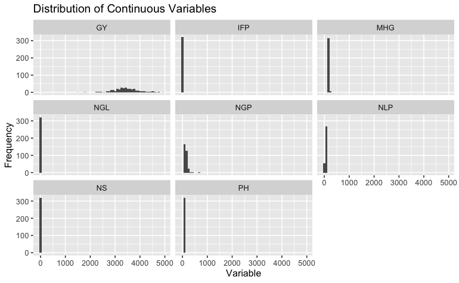

Looking at the various distributions, we can see that only grain yield (GY) has a semblance of a somewhat normal distrubtion. This is only a concern in building our multiple regression model as it requires normally distributed data as this can improve model performance. For our regression tree and SVM models, this is not a concern so that data will not need to be transformed prior to running these models. As the GY is the one variable that has a somewhat normally distributed appearance, we can test for normality using the shapiro wilk test, in addition to the other variables.

```
[1] "The column PH is not normal."
[1] "The column IFP is not normal."
[1] "The column NLP is not normal."
[1] "The column NGP is not normal."
[1] "The column NGL is not normal."
[1] "The column NS is not normal."
[1] "The column MHG is not normal."
[1] "The column GY is not normal."
```

Running a shapiro wilk test on all continuous variables returns the output that none of the distributions can be considered normal. This is concerning in the context of building our multiple regression model, however, data transformations can be conducted to mitigate this issue and improve model performance.

Next we can next look for outliers in the data frame. Using the z-score approach, the values which are 3 standard deviations or more away from the mean will be considered outliers and can be removed.

Looking at the z-scores for each continuous value, we can select for rows which contains values which are greater than 3 standard deviations. Completing this, we can see that there are 12 rows which contain outliers. These rows are now marked for removal in the data cleaning and shaping step of the process.

Next, we can look for any correlations or collinearity that might exist which could bias our multiple regression model.

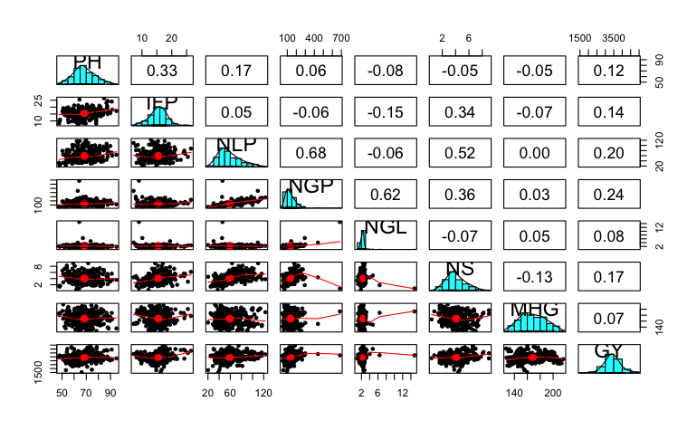